# Analyse Stress und Vitalität im Studium

Bernhard Wittmann

24.06.2017

```r
# Daten laden
data_total <- read.table(file = "data_mindset2017.csv", encoding = "UTF-8",
    header = FALSE, sep = "\t", quote = "\"", dec = ".", row.names = "CASE",
    col.names = c("CASE", "SERIAL", "REF", "QUESTNNR", "MODE", "STARTED", "ST01_01",
        "ST01_02", "ST01_03", "ST01_04", "ST01_05", "ST01_06", "ST01_07", "ST01_08",
        "ST01_09", "ST01_10", "VT01_01", "VT01_03", "VT01_04", "VT01_05", "VT01_06",
        "VT01_07", "RF01_01", "RF01_02", "RF01_03", "RF01_04", "MS01_01", "MS01_02",
        "MS01_03", "MS01_04", "MS01_05", "MS01_06", "MS01_07", "MS01_08", "SD01",
        "SD02_01", "SD15_01", "SD15_01a", "SD16", "AG04_01", "TIME001", "TIME002",
        "TIME003", "TIME004", "TIME005", "TIME006", "TIME007", "TIME008", "TIME_SUM",
        "MAILSENT", "LASTDATA", "FINISHED", "Q_VIEWER", "LASTPAGE", "MAXPAGE",
        "MISSING", "MISSREL", "TIME_RSI", "DEG_TIME"), as.is = TRUE, colClasses = c(CASE = "numeric",
        SERIAL = "character", REF = "character", QUESTNNR = "character", MODE = "character",
        STARTED = "POSIXct", ST01_01 = "numeric", ST01_02 = "numeric", ST01_03 = "numeric",
        ST01_04 = "numeric", ST01_05 = "numeric", ST01_06 = "numeric", ST01_07 = "numeric",
        ST01_08 = "numeric", ST01_09 = "numeric", ST01_10 = "numeric", VT01_01 = "numeric",
        VT01_03 = "numeric", VT01_04 = "numeric", VT01_05 = "numeric", VT01_06 = "numeric",
        VT01_07 = "numeric", RF01_01 = "numeric", RF01_02 = "numeric", RF01_03 = "numeric",
        RF01_04 = "numeric", MS01_01 = "numeric", MS01_02 = "numeric", MS01_03 = "numeric",
        MS01_04 = "numeric", MS01_05 = "numeric", MS01_06 = "numeric", MS01_07 = "numeric",
        MS01_08 = "numeric", SD01 = "numeric", SD02_01 = "numeric", SD15_01 = "character",
        SD15_01a = "logical", SD16 = "numeric", AG04_01 = "numeric", TIME001 = "integer",
        TIME002 = "integer", TIME003 = "integer", TIME004 = "integer", TIME005 = "integer",
        TIME006 = "integer", TIME007 = "integer", TIME008 = "integer", TIME_SUM = "integer",
        MAILSENT = "POSIXct", LASTDATA = "POSIXct", FINISHED = "logical", Q_VIEWER = "logical",
        LASTPAGE = "numeric", MAXPAGE = "numeric", MISSING = "numeric", MISSREL = "numeric",
        TIME_RSI = "numeric", DEG_TIME = "numeric"), skip = 1, check.names = TRUE,
    fill = TRUE, strip.white = FALSE, blank.lines.skip = TRUE, comment.char = "",
    na.strings = "")
# nicht beendete Datensätze entfernen
data_done <- subset(data_total, MAXPAGE >= 6)
# entferne Nicht Studenten
count_not_student <- nrow(subset(data_done, SD15_01a))
data_stud <- subset(data_done, !SD15_01a)
# entferne nicht gewissenhaft
min_border_gewissenhaft <- 3
count_not_gew <- nrow(subset(data_stud, AG04_01 < min_border_gewissenhaft))
data <- subset(data_stud, AG04_01 >= min_border_gewissenhaft)

decimal <- 2

# Function declaration translate öüä
translateUmlaute <- function(x) {
    x <- gsub("<e4>", "ä", x)
    x <- gsub("<f6>", "ö", x)
    x <- gsub("<fc>", "ü", x)
    return(x)
}
# tolower with exception handling
tryTolower = function(x) {
    # create missing value this is where the returned value will be
    y = ""
    test <- x
    # tryCatch error
    try_error = tryCatch(tolower(x), error = function(e) e)
    # if not an error
    if (!inherits(try_error, "error"))
        y = tolower(x)
    return(y)
}

# recode: 1,2,3,4,5 -> 5,4,3,2,1
recode = function(x) {
    return(6 - x)
}

# zentriert einen wert 1,2,3,4,5 -> -2,-1,0,1,2
center = function(x) {
    return(x - 3)
}

centerBy = function(x, by) {
    return(x - by)
}

# categorize Studiengang
cat_stud = function(x) {
    x <- gsub("^\\s+|\\s+$", "", x)
    x <- gsub("-", "", x)
    x <- tolower(x)

    x <- gsub("^(tumbwl|tum bwl)$", "TUM-BWL", x)
    x <- gsub("^(psychologie|.* psychologie)$", "Psychologie", x)
    x <- gsub("^(bwl|betriebswirtschaftslehre|.*business.*|ibs)$", "BWL", x)
    x <- gsub("^(wirtschaftspsychologie|.*wirtschaftspsychologie.*)$", "Wirtschaftspsychologie",
        x)
    x <- gsub("^.*wirtschaftsingenieur.*$", "Wirtschaftsingenieur", x)
    x <- gsub("^.*information.*$", "Informationswissenschaften", x)
    x <- gsub("^.*lehramt.*$", "Lehramt", x)
    x <- gsub("^.*biologie.*$", "Biologie", x)
    x <- gsub("^.*brau.*$", "Brauwesen", x)
    x <- gsub("^jura$", "Jura", x)
    x <- gsub("^.*marketing.*", "Marketing", x)
    x <- gsub("^.*(sport|fitness).*", "Sport", x)
    x <- gsub("^.*kommunikation.*", "Kommunikationswissenschaften", x)
    x <- gsub("^(.*bau.*|enb)$", "Bauwesen", x)
    x <- gsub("^(.*anglistik.*|.*englisch.*|.*english.*)$", "Anglistik", x)
    x <- gsub("^.*wirtschaftsmathematik.*$", "Wirtschaftsmathematik", x)
    x <- gsub("^(.*wirtschaft.*|vwl)$", "Wirtschaftswissenschaften", x)
    x <- gsub("^architektur$", "Architektur", x)
    x <- gsub("^physiotherapie$", "Physiotherapie", x)
    x <- gsub("^.*medien.*$", "Medienwissenschaften", x)
    x <- gsub("^.*sozi.*$", "Sozialwissenschaft", x)
    x <- gsub("^(internationale pr|human factors engineering|management)", "Management",
        x)
    x <- gsub("^germanistik$", "Germanistik", x)
    x <- gsub("^.*religion.*$", "Religionswissenschaften", x)
    x <- gsub("^.*agronomie.*", "Agronomie", x)
    x <- gsub("^wissenschaft$", "Wissenschaft", x)
    x <- gsub("^.*geographie.*$", "Geographie", x)
    x <- gsub("^.*touris.*", "Tourismus", x)
    # TODO weitere Studiengänge
    return(x)
}

cat_stud_category = function(x) {
    x <- gsub("^(TUM-BWL|BWL|Marketing|Wirtschaftswissenschaften|Management|Jura)$",
        "Rechts- und Wirtschaftswissenschaften", x)
    x <- gsub("^(Agronomie|Brauwesen)$", "Agrar- und Forstwissenschaften", x)
    x <- gsub("^(Psychologie|Wirtschaftspsychologie|Informationswissenschaften|Sport|Kommunikationswissenschaften|Medienwissenschaften|Geographie|Tourismus|Sozialwissenschaft)$",
        "Gesellschafts- und Sozialwissenschaften", x)
    x <- gsub("^(Wirtschaftsingenieur|Bauwesen)$", "Ingenieurwissenschaften",
        x)
    x <- gsub("^(Architektur)$", "Kunst, Gestaltung und Musik", x)
    x <- gsub("^(Lehramt)$", "Lehramtsstudiengänge", x)
    x <- gsub("^(Medizin|Physiotherapie)$", "Medizin und Gesundheitswesen",
        x)
    x <- gsub("^(Wirtschaftsmathematik|Wissenschaft|Biologie)$", "Naturwissenschaften und Mathematik
",
        x)
    x <- gsub("^(Anglistik|Germanistik|Religionswissenschaften)$", "Sprach- und Kulturwissenschaften",
        x)
    return(x)
}

# calculate growth mindset score
data <- dplyr::mutate(data, MS = recode(MS01_01) + recode(MS01_02) + MS01_03 +
    recode(MS01_04) + MS01_05 + recode(MS01_06) + MS01_07 + MS01_08 - 8)
data <- dplyr::mutate(data, MS_CENTERED = centerBy(MS, 2 * 8))

# calculate self motivation score
data <- dplyr::mutate(data, RF = RF01_01 + RF01_02 + RF01_03 + RF01_04 - 4)

# calculate stress level
data <- dplyr::mutate(data, ST = ST01_01 + ST01_02 + ST01_03 + recode(ST01_04) +
    recode(ST01_05) + ST01_06 + recode(ST01_07) + recode(ST01_08) + ST01_09 +
    ST01_10 - 10)

# calculate vitality level
data <- dplyr::mutate(data, VT = VT01_01 + VT01_03 + VT01_04 + VT01_05 + VT01_06 +
    VT01_07 - 6)

attach(data)
```

# Ziel

Ziel dieser Umfrage ist es Faktoren für die Stresswahrnehmung und Vitalität zu finden. Mögliche Faktoren dabei sind: das Growth Mindset der Person und die Fähigkeit der Selbstmotivierung.

> Anmerkung: Alle Ergebnisse werden auf 2 Nachkommastellen gerundet

# Deskriptive Auswertung

Zuerst soll eine deskriptive Analyse der erhobenen Daten durchgeführt werden.

## Stichprobe

Dieser Abschnitt soll die Stichprobe analysieren.

### Umfang

```r
# Berechnung Ursprungsumfang
length_total <- nrow(data_total)
# Berechnung gültiger Umfang
length <- nrow(data)
```

Der Umfang der Stichprobe beträgt insgesamt 120 Datensätze. Davon wurden insgesamt 101 gültige Fragebögen abgeschlossen.

Es wurden also 7 Datensätze ausgeschlossen, weil sie nicht beendet wurden. Zudem wurden weitere 11 Datensätze ausgeschlossen, die keine StudentInnen waren. Außerdem wurden 1 Datensätze ausgeschlossen, da sie laut eigenen Angaben nicht gewissenhaft beim Ausfüllen des Fragebogens waren.

### Geschlecht

```r
# Anzahl Männer
count_men <- nrow(subset(data, SD01 == 2))
# Anzahl Frauen
count_women <- nrow(subset(data, SD01 == 1))
gender_counts <- c(count_men, count_women)
# Vektor mit Porzentangaben von Männern und Frauen
percentages_gender <- round(gender_counts/sum(gender_counts) * 100)
```

Von den insgesant 101 teilnehmenden Personen waren 28 Männer (28 Prozent) und 73 Frauen (72 Prozent).

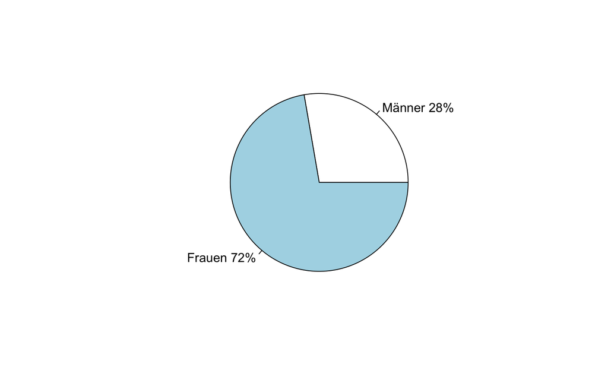

```r
labels <- c("Männer", "Frauen")

# Erstellung Kreisdiagramm aus Frauen und Männer anteil
labels <- paste(labels, percentages_gender)
labels <- paste(labels, "%", sep = "")
pie(gender_counts, labels = labels)
```

### Alter

Nun soll das Alter der teilnehmenden Personen untersucht werden. Der Mittelwert beträgt 23.48 Jahre und der Median liegt bei 23 Jahren. Der/Die jüngste Teilnehmer/-in ist 19 und der/die Älteste ist 40. Die Varianz hat dabei einen Wert von 13.85 mit einer Standardabweichung von 3.72.

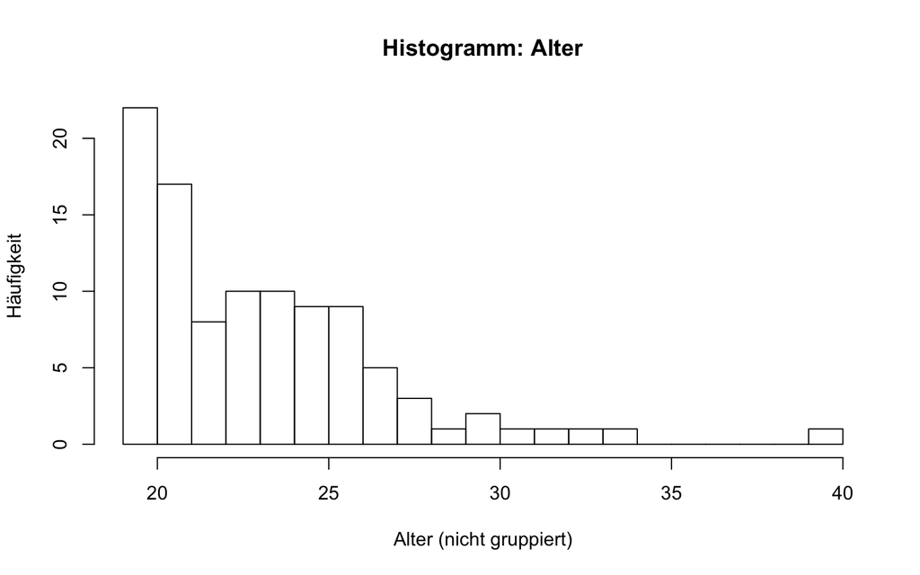

```r
# Historamm Alter
hist(SD02_01, breaks = seq(min(SD02_01), max(SD02_01), by = 1), main = "Histogramm: Alter",
    xlab = "Alter (nicht gruppiert)", ylab = "Häufigkeit")
```

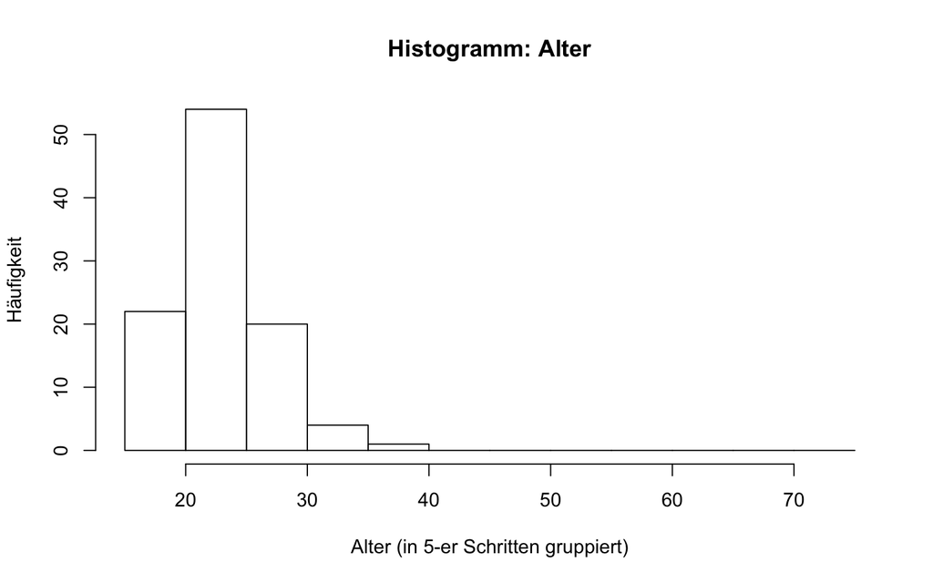

```r
# Histogramm Alter gruppiert
hist(SD02_01, breaks = seq(15, 75, by = 5), main = "Histogramm: Alter", xlab = "Alter (in 5-er Schritten gruppiert)",
    ylab = "Häufigkeit")
```

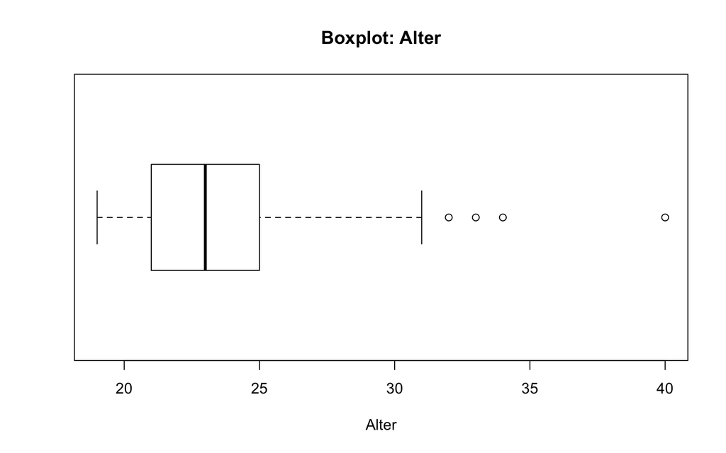

```r
boxplot(SD02_01, main = "Boxplot: Alter", xlab = "Alter", horizontal = TRUE)
```

### Studiengänge

Die Verteilung der Studiengänge soll analysiert werden

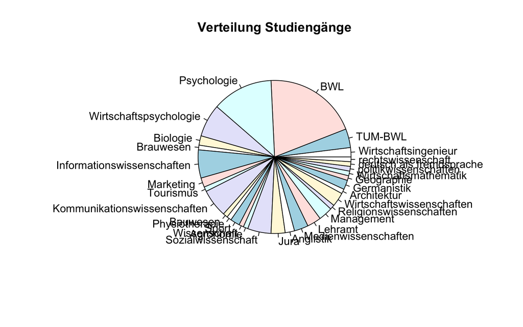

```r
# Studiengänge zusammenfassen
data <- dplyr::mutate(data, STUD = cat_stud(SD15_01))
data <- dplyr::mutate(data, STUD_CAT = cat_stud_category(STUD))
labels <- unique(data$STUD)
# Studiengänge einzeln
count_studiengaenge <- c()

for (label in labels) {
    count_studiengaenge[label] <- nrow(subset(data, STUD == label))
}

pie(count_studiengaenge, main = "Verteilung Studiengänge", labels = labels)
```

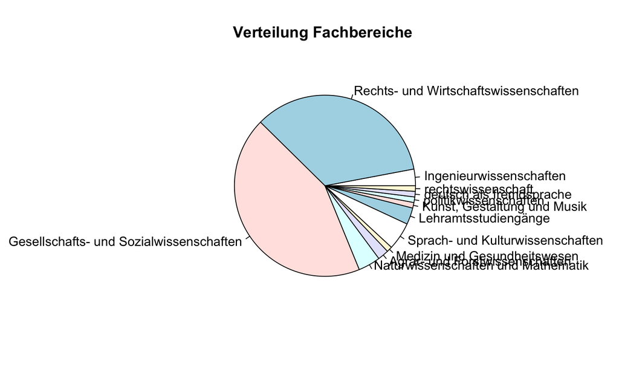

```r
# Studiengänge gruppiert
labels <- unique(data$STUD_CAT)
count_studiengaenge <- c()

for (label in labels) {
    count_studiengaenge[label] <- nrow(subset(data, STUD_CAT == label))
}

pie(count_studiengaenge, main = "Verteilung Fachbereiche ", labels = labels)
```

### Art des Studiengangs

Die Verteilung zwischen Bachelor und Master - Studiengängen soll analysiert werden

```r
count_bachelor <- nrow(subset(data, SD16 == 1))
count_master <- nrow(subset(data, SD16 == 2))
count_bachelor_master <- c(count_bachelor, count_master)
percentages_bachelor_master <- round(count_bachelor_master/sum(count_bachelor_master) *
    100)
```

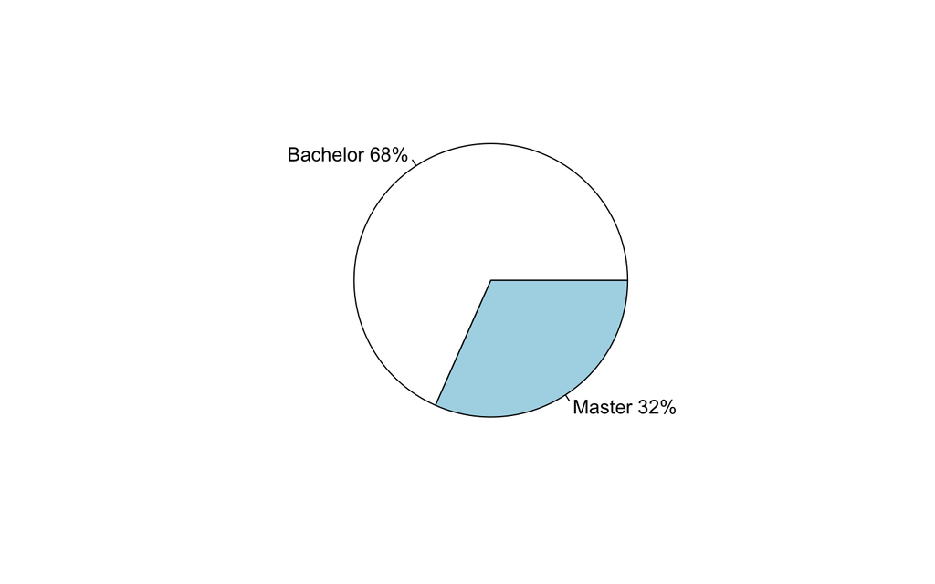

```r
labels <- c("Bachelor", "Master")

labels <- paste(labels, percentages_bachelor_master)
labels <- paste(labels, "%", sep = "")
pie(count_bachelor_master, labels = labels)
```

## Faktoren/Prädiktoren

Jetzt sollen die Faktoren/Prädiktoren beschrieben und analysiert werden.

### Growth Mindset

Der Testwert für das Growth Mindset ergibt sich durch ein Aufsummieren aller Items (Antwortmöglichkeiten 0-4). Dabei müssen jedoch die Items zu einem statischen Mindset rekodiert werden. Die Werte werden hier zur besseren Versändlichkeit zentriert angegeben. Ein negativer Wert bedeutet also ein statisches Mindset, während ein positiver ein dynamisches Mindset.

Der Median beträgt dabei -1 und der Mittelwert -0.65. Die Varianz hat dabei einen Wert von 47.25 mit einer Standardabweichung von 6.87.

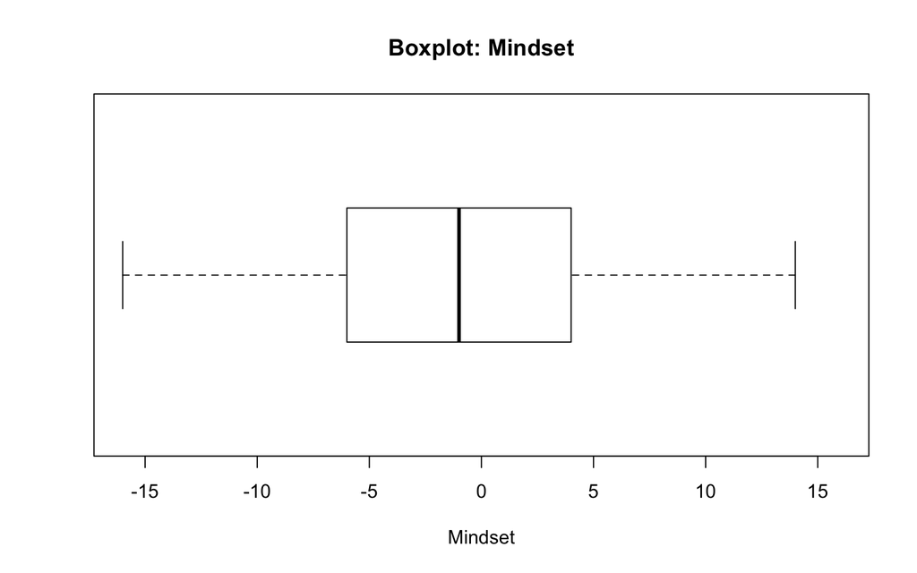

```r
boxplot(MS_CENTERED, main = "Boxplot: Mindset", xlab = "Mindset", horizontal = TRUE,
    ylim = c(-2 * 8, 2 * 8))
```

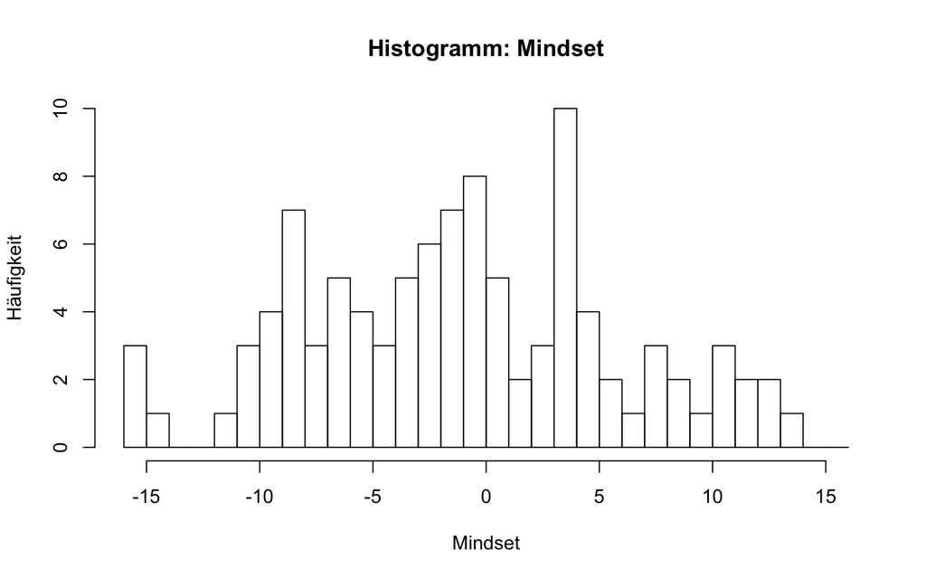

```r
hist(MS_CENTERED, breaks = seq(-16, 16, by = 1), main = "Histogramm: Mindset",
    xlab = "Mindset", ylab = "Häufigkeit")
```

### Positive Selbstmotivierung

Der Testwert für die Positiven Selbstmotivierung ergibt sich durch ein Aufsummieren aller Items (Antwortmöglichkeiten 0-3).

Der Median beträgt dabei 6 und der Mittelwert 5.87. Die Varianz hat dabei einen Wert von 6.59 mit einer Standardabweichung von 2.57.

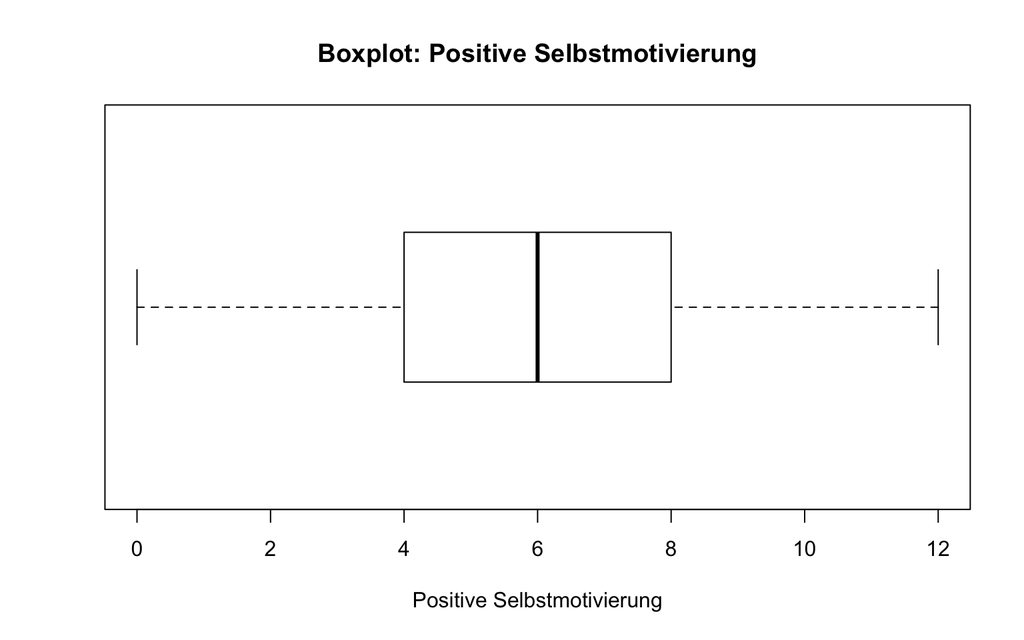

```r
boxplot(RF, main = "Boxplot: Positive Selbstmotivierung", xlab = "Positive Selbstmotivierung",
    horizontal = TRUE, ylim = c(0, 3 * 4))
```

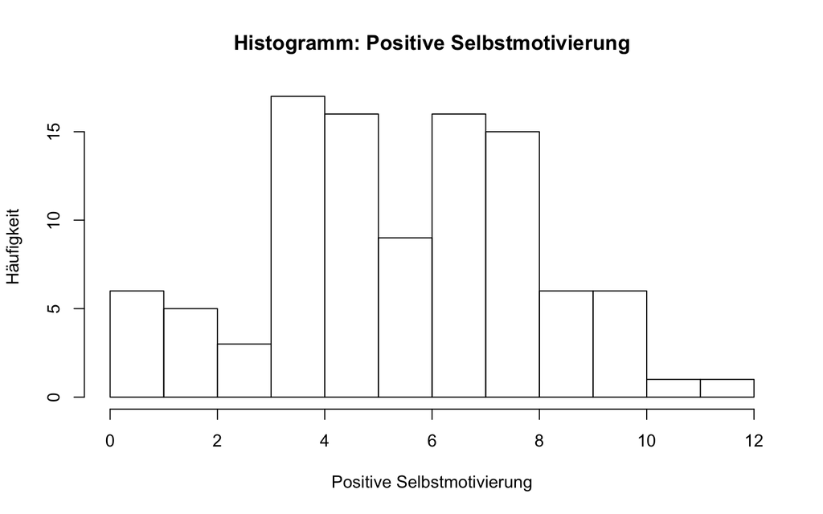

```r
hist(RF, breaks = seq(0, 12, by = 1), main = "Histogramm: Positive Selbstmotivierung",
    xlab = "Positive Selbstmotivierung", ylab = "Häufigkeit")
```

### Stress

Der Testwert für das Stresslevel ergibt sich durch ein Aufsummieren aller Items (Antwortmöglichkeiten 0-4). Ein höherer Wert bedeutet, also auch ein höheres Stresslevel

Der Median beträgt dabei 18 und der Mittelwert 17.69. Die Varianz hat dabei einen Wert von 50.69 mit einer Standardabweichung von 7.12.

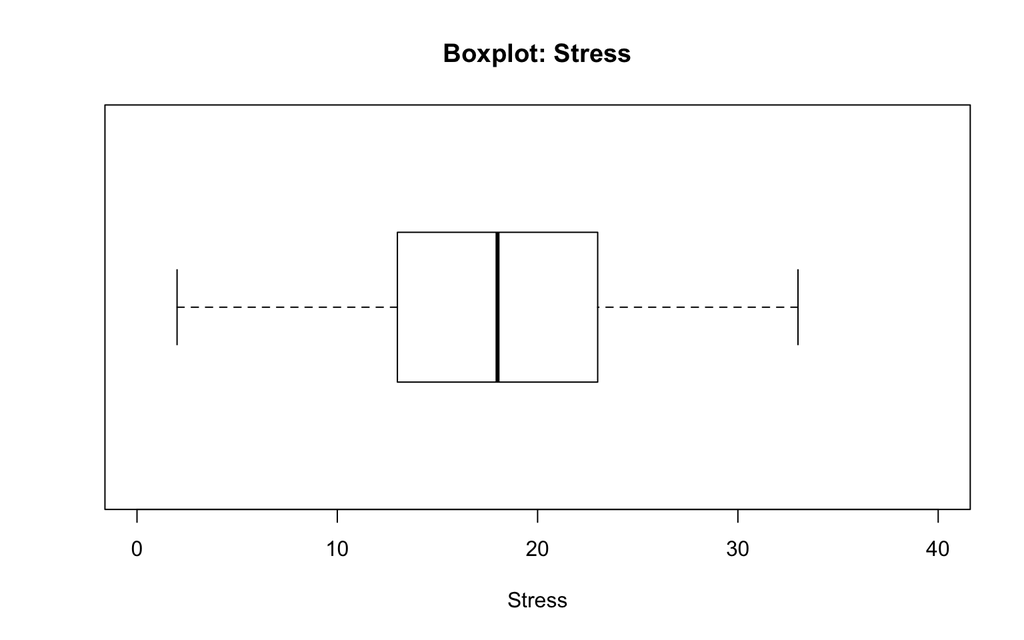

```r
boxplot(ST, main = "Boxplot: Stress", xlab = "Stress", horizontal = TRUE, ylim = c(0,
    40))
```

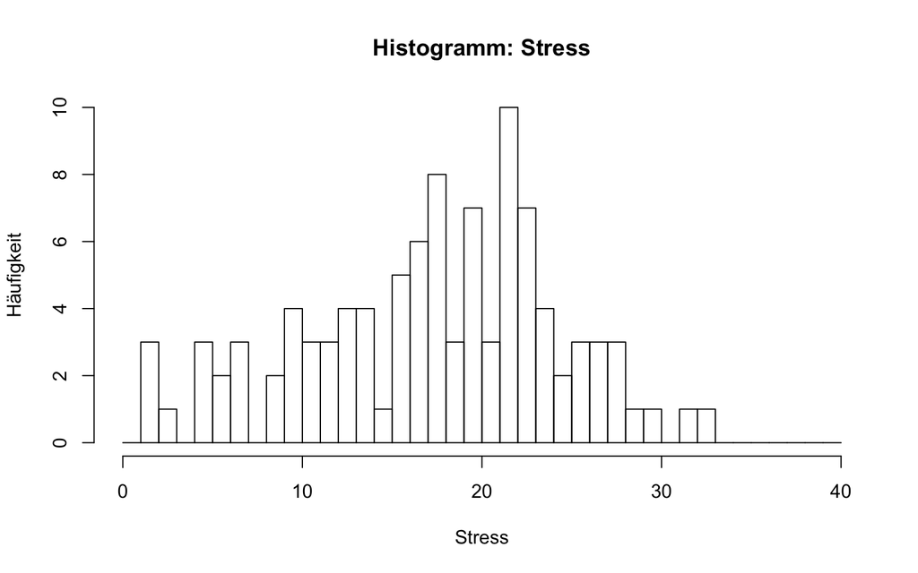

```r
hist(ST, breaks = seq(0, 40, by = 1), main = "Histogramm: Stress", xlab = "Stress",
    ylab = "Häufigkeit")
```

### Vitalität

Der Testwert für die Vitalität ergibt sich durch ein Aufsummieren aller Items (Antwortmöglichkeiten 0-4). Ein höherer Wert bedeutet, also auch eine höhere Vitalität

Der Median beträgt dabei 12 und der Mittelwert 11.84. Die Varianz hat dabei einen Wert von 24.87 mit einer Standardabweichung von 4.99.

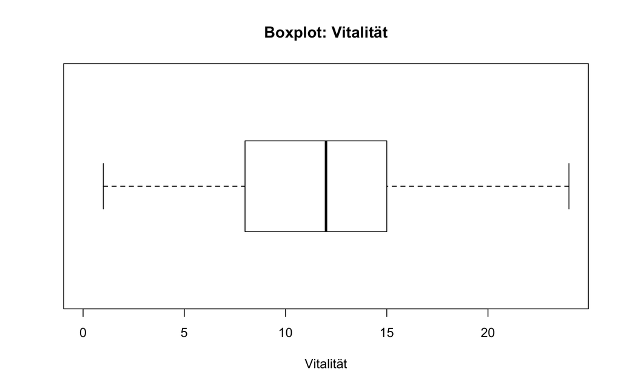

```r
boxplot(VT, main = "Boxplot: Vitalität", xlab = "Vitalität", horizontal = TRUE,
    ylim = c(0, 4 * 6))
```

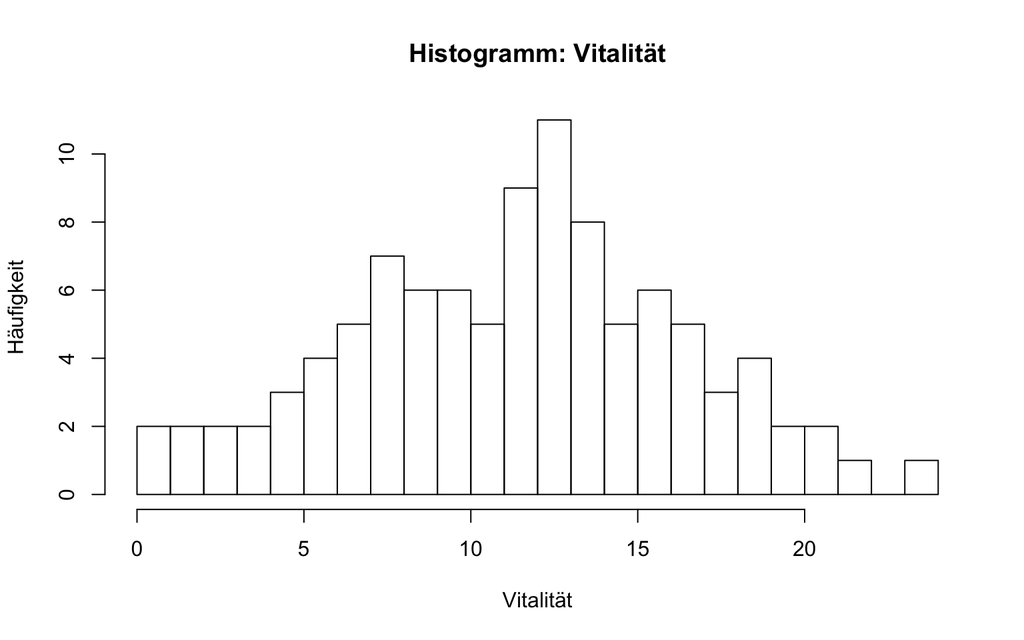

```r
hist(VT, breaks = seq(0, 4 * 6, by = 1), main = "Histogramm: Vitalität", xlab = "Vitalität",
    ylab = "Häufigkeit")
```

# Korrelation

```r
# gather data
regression_data_1 <- dplyr::select(data, MS, RF, ST)
regression_data_2 <- dplyr::select(data, MS, RF, VT)
```

Es soll nun die Korrelation zwischen den Prädiktoren und den Variablen gezeigt werden.

## Korrelation (Variable: Stress)

```r
labels = c("Mindset", "Selbstmotivierung", "Stress")
cor_1 <- round(cor(regression_data_1), decimal)
rownames(cor_1) <- labels
colnames(cor_1) <- labels

knitr::kable(cor_1, format = "html", table.attr = "class=\"table-th-left\"")
```

|  | Mindset | Selbstmotivierung | Stress |
| --- | --- | --- | --- |
| Mindset | 1.00 | 0.07 | 0.08 |
| Selbstmotivierung | 0.07 | 1.00 | -0.37 |
| Stress | 0.08 | -0.37 | 1.00 |

## Korrelation (Variable: Vitalität)

```r
labels = c("Mindset", "Selbstmotivierung", "Vitalität")
cor_2 <- round(cor(regression_data_2), decimal)
rownames(cor_2) <- labels
colnames(cor_2) <- labels

knitr::kable(cor_2, format = "html", table.attr = "class=\"table-th-left\"")
```

|  | Mindset | Selbstmotivierung | Vitalität |
| --- | --- | --- | --- |
| Mindset | 1.00 | 0.07 | 0.10 |
| Selbstmotivierung | 0.07 | 1.00 | 0.47 |
| Vitalität | 0.10 | 0.47 | 1.00 |

# Regressionsanalyse

Nun soll versucht werden einen Zusammenhang zwischen Prädiktoren und Variablen mittels Regressionsanalysen herzustellen.

```r
# Standardize regression_data
regression_data_1_scaled <- data.frame(scale(regression_data_1))
regression_data_2_scaled <- data.frame(scale(regression_data_2))
```

## Multiple Regression (Variable: Stress)

```r
model1 <- lm(ST ~ MS + RF, data = regression_data_1_scaled)
summary(model1)
```

```
##
## Call:
## lm(formula = ST ~ MS + RF, data = regression_data_1_scaled)
##
## Residuals:
##      Min       1Q   Median       3Q      Max
## -2.33542 -0.67333  0.05151  0.70787  2.08030
##
## Coefficients:
##               Estimate Std. Error t value Pr(>|t|)
## (Intercept)  1.505e-16  9.261e-02   0.000    1.000
## MS           1.078e-01  9.331e-02   1.155    0.251
## RF          -3.814e-01  9.331e-02  -4.087 8.95e-05 ***
## ---
## Signif. codes:  0 '***' 0.001 '**' 0.01 '*' 0.05 '.' 0.1 ' ' 1
##
## Residual standard error: 0.9307 on 98 degrees of freedom
## Multiple R-squared:  0.1511, Adjusted R-squared:  0.1338
## F-statistic: 8.723 on 2 and 98 DF,  p-value: 0.0003262
```

```r
model1_coef <- round(coef(model1), decimal)
```

### ANOVA

```r
anova(model1)
```

```
## Analysis of Variance Table
##
## Response: ST
##           Df Sum Sq Mean Sq F value    Pr(>F)
## MS         1  0.644  0.6440  0.7434    0.3907
## RF         1 14.468 14.4681 16.7029 8.953e-05 ***
## Residuals 98 84.888  0.8662
## ---
## Signif. codes:  0 '***' 0.001 '**' 0.01 '*' 0.05 '.' 0.1 ' ' 1
```

## Multiple Regression (Variable: Vitalität)

```r
model2 <- lm(VT ~ MS + RF, data = regression_data_2_scaled)
summary(model2)
```

```
##
## Call:
## lm(formula = VT ~ MS + RF, data = regression_data_2_scaled)
##
## Residuals:
##      Min       1Q   Median       3Q      Max
## -2.57239 -0.57673 -0.02912  0.63379  2.04848
##
## Coefficients:
##              Estimate Std. Error t value Pr(>|t|)
## (Intercept) 1.612e-17  8.865e-02   0.000    1.000
## MS          6.390e-02  8.933e-02   0.715    0.476
## RF          4.623e-01  8.933e-02   5.175 1.21e-06 ***
## ---
## Signif. codes:  0 '***' 0.001 '**' 0.01 '*' 0.05 '.' 0.1 ' ' 1
##
## Residual standard error: 0.891 on 98 degrees of freedom
## Multiple R-squared:  0.2221, Adjusted R-squared:  0.2062
## F-statistic: 13.99 on 2 and 98 DF,  p-value: 4.532e-06
```

```r
model2_coef <- round(coef(model2), decimal)
```

### ANOVA

```r
anova(model2)
```

```
## Analysis of Variance Table
##
## Response: VT
##           Df Sum Sq Mean Sq F value    Pr(>F)
## MS         1  0.947  0.9466  1.1925    0.2775
## RF         1 21.260 21.2597 26.7817 1.212e-06 ***
## Residuals 98 77.794  0.7938
## ---
## Signif. codes:  0 '***' 0.001 '**' 0.01 '*' 0.05 '.' 0.1 ' ' 1
```

##### *Fragen? E-Mail an b.wittmann@tum.de*